## Milestone Project for Data Science Capstone

### Report purpose

The goal of this project is just to display that you’ve gotten used to working with the data and that you are on track to create your prediction algorithm. Please submit a report on R Pubs (http://rpubs.com/) that explains your exploratory analysis and your goals for the eventual app and algorithm. This document should be concise and explain only the major features of the data you have identified and briefly summarize your plans for creating the prediction algorithm and Shiny app in a way that would be understandable to a non-data scientist manager. You should make use of tables and plots to illustrate important summaries of the data set.

The motivation for this project is to:

1- Demonstrate that you’ve downloaded the data and have successfully loaded it in.  
2- Create a basic report of summary statistics about the data sets.  
3- Report any interesting findings that you amassed so far.  
4- Get feedback on your plans for creating a prediction algorithm and Shiny app.

```r
knitr::opts_chunk$set(echo = TRUE)
```

### Load Data & Sample

Data set Downloading and Loading into R Download the data from following link and unzip the files in the current working directory - https://d396qusza40orc.cloudfront.net/dsscapstone/dataset/Coursera-SwiftKey.zip

```r
setwd("E:/Documents/new_repo/Data-Science-Capston/final/en_US")

    con <- file("en_US.news.txt", open="r")
    En_US_NEWS_text <- readLines(con); close(con)
    con <- file("en_US.blogs.txt", open="r")
    En_US_blogs_text <- readLines(con); close(con)

    con <- file("en_US.twitter.txt", open="r")
    En_Twit_text <- readLines(con); close(con)
```

Extracting the following text files summary

- en_US.news.txt
- en_US.blogs.txt
- en_US.twitter.txt

```r
file_stat<- function(text_file, lines) {
    f_size <- file.info(text_file)[1]/1024^2
    nchars <- lapply(lines, nchar)
    maxchars <- which.max(nchars)
    word_count <- sum(sapply(strsplit(lines, "\\s+"), length))
    return(c(text_file, format(round(as.double(f_size), 2), nsmall=2), length(lines),maxchars, word_count))
}

    En_US_news_stat<- file_stat("en_US.news.txt", En_US_NEWS_text)
    En_US_blogs_stat <- file_stat("en_US.blogs.txt", En_US_blogs_text)
    En_Twit_text_stat<- file_stat("en_US.twitter.txt", En_Twit_text)

    test_summary <- c(En_US_news_stat, En_US_blogs_stat,En_Twit_text_stat)

    df <- data.frame(matrix(unlist(test_summary), nrow=3, byrow=T))
    colnames(df) <- c("Text_file", "Size(MB)", "Line_Count", "Max Line Length", "Words_Count")
    print(df)
```

```
##           Text_file Size(MB) Line_Count Max Line Length Words_Count
## 1    en_US.news.txt       NA      77259           14556     2643972
## 2   en_US.blogs.txt       NA     899288          483415    37334441
## 3 en_US.twitter.txt       NA    2360148         1484357    30373792
```

### Exploratory data analysis

Here I am writing a functions to make the test data Corpus, Clean the corpus, and capture the hight frquency words

```r
make_Corpus<- function(test_file) {
    gen_corp<- paste(test_file, collapse=" ")
    gen_corp <- VectorSource(gen_corp)
    gen_corp <- Corpus(gen_corp)
}

clean_corp <- function(corp_data) {

    corp_data <- tm_map(corp_data, removeNumbers)
    corp_data <- tm_map(corp_data, content_transformer(tolower))
    corp_data <- tm_map(corp_data, removeWords, stopwords("english"))
    corp_data <- tm_map(corp_data, removePunctuation)
    corp_data <- tm_map(corp_data, stripWhitespace)
    return (corp_data)
}

high_freq_words <- function (corp_data) {
    term_sparse <- DocumentTermMatrix(corp_data)
    term_matrix <- as.matrix(term_sparse)   ## convert our term-document-matrix into a normal matrix
    freq_words <- colSums(term_matrix)
    freq_words <- as.data.frame(sort(freq_words, decreasing=TRUE))
    freq_words$word <- rownames(freq_words)
    colnames(freq_words) <- c("Frequency","word")
    return (freq_words)
}
```

### Bar Chart of High frequency words

This section is explore the different text mining commads and extract the high frequency words

```r
## en_US.news.txt High frequency words
    En_US_NEWS_text1<-sample(En_US_NEWS_text, round(0.1*length(En_US_NEWS_text)), replace = F)
    US_news_corpus <- make_Corpus(En_US_NEWS_text1)
    US_news_corpus <- clean_corp(US_news_corpus)
```

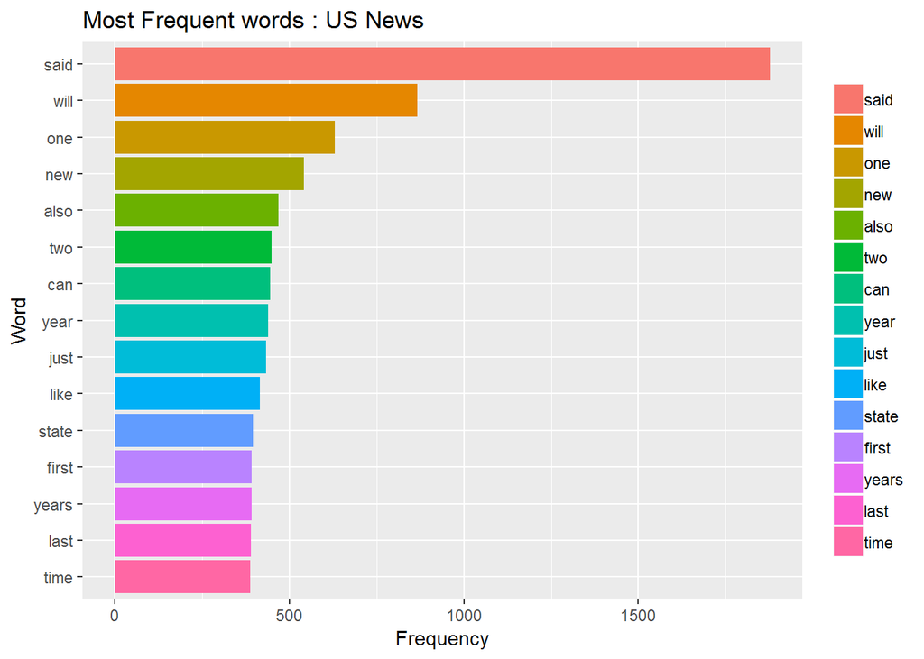

```r
    US_news_most_used_word <- high_freq_words(US_news_corpus)
    US_news_most_used_word1<- US_news_most_used_word[1:15,]

    p<-ggplot(data=US_news_most_used_word1, aes(x=reorder(word,Frequency), y=Frequency,
                    fill=factor(reorder(word,-Frequency))))+ geom_bar(stat="identity")
    p + xlab("Word") +labs(title = "Most Frequent words : US News") +theme(legend.title=element_blank()) + coord_flip()
```

```r
## en_US.blogs.txt High frequency words
    En_US_blogs_text1<-sample(En_US_blogs_text, round(0.1*length(En_US_blogs_text)), replace = F)
    US_blogs_corpus <- make_Corpus(En_US_blogs_text1)
    US_blogs_corpus <- clean_corp(US_blogs_corpus)
```

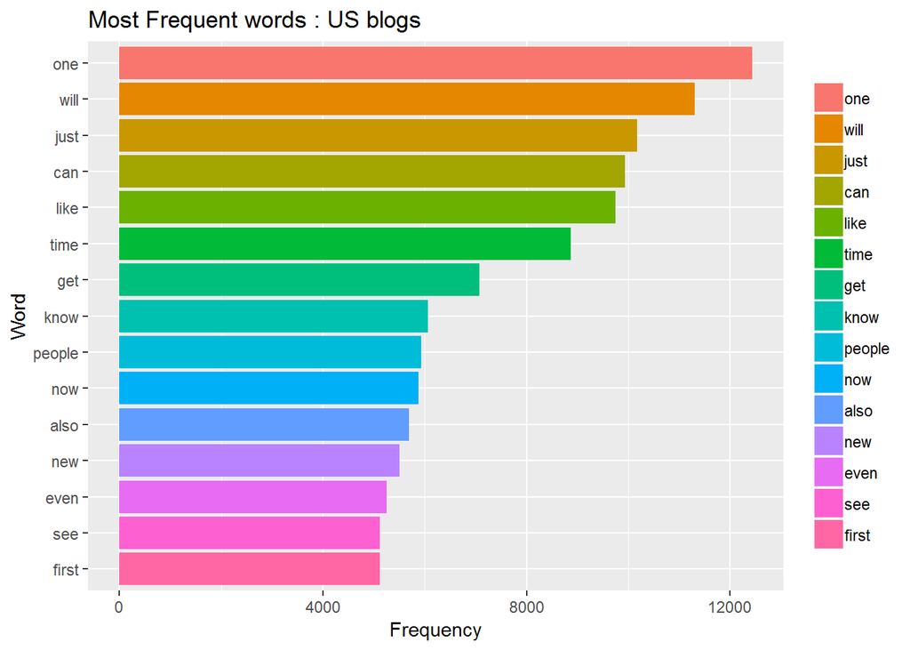

```r
    US_blogs_most_used_word <- high_freq_words(US_blogs_corpus)
    US_blogs_most_used_word1<- US_blogs_most_used_word[1:15,]

    p<-ggplot(data=US_blogs_most_used_word1, aes(x=reorder(word,Frequency), y=Frequency,
                    fill=factor(reorder(word,-Frequency))))+ geom_bar(stat="identity")
    p + xlab("Word") +labs(title = "Most Frequent words : US blogs") +theme(legend.title=element_blank()) + coord_flip()
```

```r
## en_US.twitter.txt High frequency words
    En_Twit_text1<-sample(En_Twit_text, round(0.1*length(En_Twit_text)), replace = F)
    twitter_corpus <- make_Corpus(En_Twit_text1)
    twitter_corpus <- clean_corp(twitter_corpus)
```

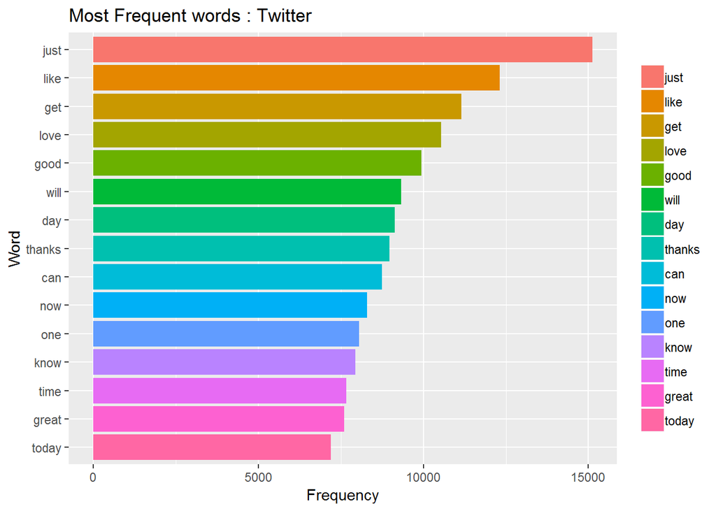

```r
    twitter_most_used_word <- high_freq_words(twitter_corpus)
    twitter_most_used_word1<- twitter_most_used_word[1:15,]

    p<-ggplot(data=twitter_most_used_word1, aes(x=reorder(word,Frequency), y=Frequency,
                    fill=factor(reorder(word,-Frequency))))+ geom_bar(stat="identity")
    p + xlab("Word") +labs(title = "Most Frequent words : Twitter") +theme(legend.title=element_blank()) + coord_flip()
```

Generating the Word Cloud Word Cloud is Cool representation of the Word display based on the Frequencies.

```r
## US News Word Cloud
library(wordcloud)
library(tokenizers)
library(stopwords)
library(quanteda)
(library(plyr))
```

[output not shown]

```r
(library(dplyr))
```

[output not shown]

```r
(library(stringi))
```

[output not shown]

```r
(library(igraph))
```

[output not shown]

```r
(library(NLP))
```

[output not shown]

```r
(library(tm))
```

[output not shown]

```r
(library(xtable))
```

[output not shown]

```r
(library(knitr))
```

[output not shown]

```r
(library(SnowballC))
```

[output not shown]

```r
(library(RWeka))
```

[output not shown]

```r
(library(ggplot2))
```

[output not shown]

```r
(library(grid))
```

[output not shown]

```r
(library(wordcloud))
```

[output not shown]

```r
(library(RColorBrewer))
```

[output not shown]

```r
(library(doParallel))
```

[output not shown]

```r
(library(slam))
```

[output not shown]

```r
(library(rvest))
```

[output not shown]

```r
(library(pipeR))
```

[output not shown]

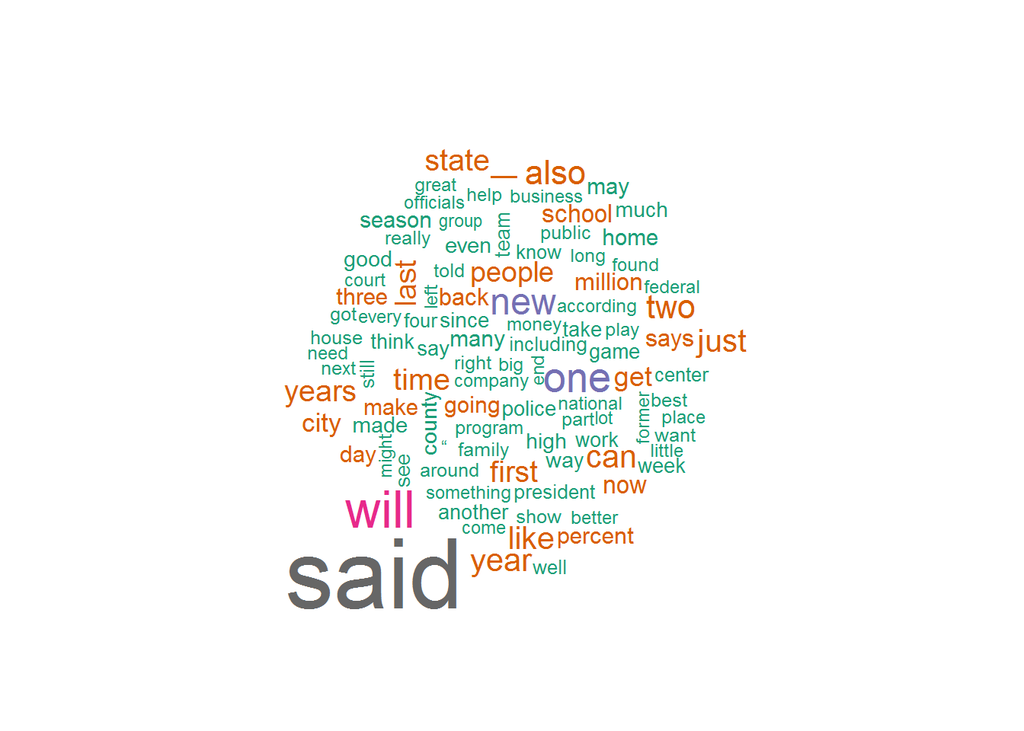

```r
    wordcloud(US_news_most_used_word$word[1:100], US_news_most_used_word$Frequency[1:100],
              colors=brewer.pal(8, "Dark2"))
```

[figure not shown]

```r
## US News Word Cloud
    wordcloud(US_blogs_most_used_word$word[1:100], US_blogs_most_used_word$Frequency[1:100],
              colors=brewer.pal(8, "Dark2"))
```

[figure not shown]

```r
## US Twitter Word Cloud
wordcloud(twitter_most_used_word$word[1:100], twitter_most_used_word$Frequency[1:100],
              colors=brewer.pal(8, "Dark2"))
```

Word Analysis For the Data analysis of text document we need to create a bag of word matrices with Unigram, Bigram, Trigrams. These Ngram model set improve the predictabily of the data analysis.

```r
## en_US.news.txt High frequency words
    En_US_NEWS_text1<-sample(En_US_NEWS_text, round(0.01*length(En_US_NEWS_text)), replace = F)
    US_News_tokens<- tokens(En_US_NEWS_text1,what ="word", remove_numbers = TRUE,
                            remove_punct = TRUE, remove_separators = TRUE, remove_symbols =TRUE )
    US_News_tokens <- tokens_tolower(US_News_tokens)
    US_News_tokens <- tokens_select(US_News_tokens, stopwords(),selection ="remove")

    US_News_unigram <- tokens_ngrams(US_News_tokens, n=1)  ## unigram
    US_News_unigram.dfm <- dfm(US_News_unigram, tolower =TRUE, remove = stopwords("english"),
                              remove_punct = TRUE)

    US_News_bigram <- tokens_ngrams(US_News_tokens, n=2)  ## bigram
    US_News_bigram.dfm <- dfm(US_News_bigram, tolower =TRUE, remove = stopwords("english"),
                              remove_punct = TRUE)

    US_News_trigram <- tokens_ngrams(US_News_tokens, n=3)  ## trigram
    US_News_trigram.dfm <- dfm(US_News_trigram, tolower =TRUE, remove = stopwords("english"),
                              remove_punct = TRUE)
    topfeatures(US_News_unigram.dfm, 20)  # 20 top US News Unigram words
```

```
##   said      â    one      s    can   also    new   time   like   just
##    191     97     66     58     50     48     46     45     44     41
##   last    two  state  first  years people   city  going    now  three
##     39     39     38     37     37     34     33     31     31     31
```

```r
        topfeatures(US_News_bigram.dfm, 20)  # 20 top US News Bigram words
```

```
##         new_york         st_louis        last_week      los_angeles
##                9                9                8                7
##       new_jersey      coming_back           â_said          thatâ_s
##                5                5                5                4
##   officials_said    atlantic_city             iâ_m attorney_general
##                4                4                4                4
##      even_though       super_bowl  general_manager       ohio_state
##                4                4                4                4
##      police_said       four_years      three_years            heâ_s
##                4                4                4                4
```

```r
           topfeatures(US_News_trigram.dfm, 20)  # 20 top US News Trigram words
```

```
##                         â_said_â               overall_draft_pick
##                                3                                2
##               extra_virgin_olive                 virgin_olive_oil
##                                2                                2
##            health_human_services                   want_just_like
##                                2                                2
##                 slovak_parish_st             never_heard_anything
##                                2                                2
##              heard_anything_like                coach_byron_scott
##                                2                                2
##                 byron_scott_said                        â_lang_ni
##                                2                                2
##                      lang_ni_def               one_two_candidates
##                                2                                2
##        two_candidates_democratic candidates_democratic_nomination
##                                2                                2
##                      think_heâ_s             can_force_individual
##                                2                                2
##                     put_us_solid                  us_solid_ground
##                                1                                1
```

```r
           ## en_US.blog.txt High frequency words
    En_US_blogs_text1<-sample(En_US_blogs_text, round(0.02*length(En_US_blogs_text)), replace = F)
    US_blogs_tokens<- tokens(En_US_blogs_text1,what ="word", remove_numbers = TRUE,
                            remove_punct = TRUE, remove_separators = TRUE, remove_symbols =TRUE )
    US_blogs_tokens <- tokens_tolower(US_blogs_tokens)
    US_blogs_tokens <- tokens_select(US_blogs_tokens, stopwords(),selection ="remove")

    US_blogs_unigram <- tokens_ngrams(US_blogs_tokens, n=1)  ## unigram
    US_blogs_unigram.dfm <- dfm(US_blogs_unigram, tolower =TRUE, remove = stopwords("english"),
                              remove_punct = TRUE)

    US_blogs_bigram <- tokens_ngrams(US_blogs_tokens, n=2)  ## bigram
    US_blogs_bigram.dfm <- dfm(US_blogs_bigram, tolower =TRUE, remove = stopwords("english"),
                              remove_punct = TRUE)

    US_blogs_trigram <- tokens_ngrams(US_blogs_tokens, n=3)  ## tiigram
    US_blogs_trigram.dfm <- dfm(US_blogs_trigram, tolower =TRUE, remove = stopwords("english"),
                              remove_punct = TRUE)
    topfeatures(US_blogs_unigram.dfm, 20)  # 20 top US blogs Unigram words
```

```
##      â      s    one   like   just    can      t   time    get   know
##   4649   3297   2533   2008   1943   1917   1870   1781   1385   1164
##    now people   also    new  first   even   make   back   much    day
##   1151   1147   1086   1080   1033   1009   1002   1002    990    989
```

```r
     topfeatures(US_blogs_bigram.dfm, 20)  # 20 top US blogs Bigram words
```

```
##      itâ_s     donâ_t       iâ_m    didnâ_t      iâ_ve    thatâ_s
##        727        513        470        278        260        217
##     canâ_t   doesnâ_t    youâ_re    wasnâ_t   thereâ_s     said_â
##        181        162        137        133        124        124
##       â_œi     isnâ_t  years_ago      iâ_ll     â_œthe       iâ_d
##        120        120        119        117        115        115
##      heâ_s first_time
##        107        102
```

```r
      topfeatures(US_blogs_trigram.dfm, 20)  # 20 top US blogs Trigram words
```

```
##   donâ_t_know     iâ_m_sure    iâ_m_going   donâ_t_want  donâ_t_think
##            47            43            38            35            34
##  didnâ_t_know    itâ_s_just   think_itâ_s       â_itâ_s    itâ_s_hard
##            29            29            21            20            20
##  didnâ_t_want      â_œitâ_s    itâ_s_like       â_œiâ_m    itâ_s_time
##            20            19            18            17            17
##   donâ_t_like     iâ_d_like doesnâ_t_mean    donâ_t_get      now_iâ_m
##            16            15            15            14            13
```

```r
      ## en_US.twitter.txt Ngram words
    En_Twit_text1<-sample(En_Twit_text, round(0.02*length(En_Twit_text)), replace = F)
    twitter_tokens<- tokens(En_Twit_text1,what ="word", remove_numbers = TRUE,
                            remove_punct = TRUE, remove_separators = TRUE, remove_symbols =TRUE )
    twitter_tokens <- tokens_tolower(twitter_tokens)
    twitter_tokens <- tokens_select(twitter_tokens, stopwords(),selection ="remove")

    twitter_unigram <- tokens_ngrams(twitter_tokens, n=1)  ## unigram
    twitter_unigram.dfm <- dfm(twitter_unigram, tolower =TRUE, remove = stopwords("english"),
                              remove_punct = TRUE)

    twitter_bigram <- tokens_ngrams(twitter_tokens, n=2)  ## bigram
    twitter_bigram.dfm <- dfm(twitter_bigram, tolower =TRUE, remove = stopwords("english"),
                              remove_punct = TRUE)

    twitter_trigram <- tokens_ngrams(twitter_tokens, n=3)  ## trigram
    twitter_trigram.dfm <- dfm(twitter_trigram, tolower =TRUE, remove = stopwords("english"),
                              remove_punct = TRUE)
    topfeatures(twitter_unigram.dfm, 20)  # 20 top Unigram words
```

```
##   just   like    get   love   good    day thanks    can     rt    one
##   2926   2428   2284   2165   1994   1873   1805   1764   1732   1701
##   know    now      u   time  great  today     go    lol    new    see
##   1661   1627   1577   1524   1523   1454   1418   1386   1333   1300
```

```r
      topfeatures(twitter_bigram.dfm, 20)  # 20 top Bigram words
```

```
##              â_œ        right_now       last_night  looking_forward
##              447              337              238              188
##   happy_birthday        feel_like     good_morning         just_got
##              166              160              158              147
##    thanks_follow       looks_like         let_know        good_luck
##              124              122              117              115
##      follow_back          can_get        great_day thanks_following
##              108              103               92               89
##        next_week    please_follow      sounds_like        make_sure
##               87               84               80               76
```

```r
      topfeatures(twitter_trigram.dfm, 20)  # 20 top  Trigram words
```

```
##            let_us_know      happy_mothers_day     happy_mother's_day
##                     51                     37                     36
##         happy_new_year                 rt_â_œ            fun_fun_fun
##                     35                     23                     23
##                  â_â_â  good_morning_everyone                  x_x_x
##                     20                     18                     18
## looking_forward_seeing         vote_vote_vote               la_la_la
##                     17                     15                     15
##          cinco_de_mayo          just_got_back    ralph_waldo_emerson
##                     14                     13                     12
##     follow_back_please          just_got_done    thanks_following_us
##                     11                     10                     10
##   please_please_follow          just_got_home
##                     10                     10
```

Interesting findings that you amassed so far I have gone through the multiple literatures and youtube vidios on Text mining and “quanteda” library With Small text data sets problems how the data set will get exploded with different ngrams and Bag of words. I found quanteda library is very useful in generating the text analytics. Which very fast compare to TM library. This project motivated me to work on small samples sets to establish the my code.

Get feedback on your plans for creating a prediction algorithm and Shiny app. Plan of Approach: - Tockenization and bag of words with multiple Ngrams. - Since We need build the shiny app which have limitation on resources. I will use the small sample (~ 1 to 5%). - I will explore the options for data compression. Run the Machine Learning programs to develop the predictive model. - Explore the options to improve the accuracy and speed of execution. Feedback: - Highly appreciate your valuable feedback on this approach and your recommendations.